# xgxr Overview

Andrew Stein, Fariba Khanshan, Alison Margolskee

2023-03-22

## Overview

The xgxr package supports a structured approach to exploring PKPD data ([outlined here](https://opensource.nibr.com/xgx/)). It also contains helper functions for enabling the modeler to follow best R practices (by appending the program name, figure name location, and draft status to each plot) and enabling the modeler to follow best graphical practices (by providing an xgx theme that reduces chart ink, and by providing time-scale, log-scale, and reverse-log-transform-scale functions for more readable axes).

## Required Packages

```r
library(tidyr)
library(dplyr)
library(ggplot2)
library(xgxr)
```

## Traceability: annotating and saving plots and tables

### Saving figures

Our best practices require that we mark plots as “DRAFT” if not yet final, and also list the program that created the plot and the location where the plot is stored. This helps with the traceability of the work, by ensuring that the following information is available for every plot in a report: the R script used to create the figure, the location where the figure is stored, and the time and date when the figure was created. The key functions here are: * `xgx_annotate_status` allows for the addition of text (like the word draft) to the plots * `xgx_annotate_filenames` allows for printing the filenames as a caption for the plot. It requires an input list `dirs` with particular fields, as shown below.

The function `xgx_save` calls both of the above functions and it is illustrated below.

This function also requires the user to input a width and height for the graph. This is because often, the plots that are created have font that is so small that it’s impossible to read the x and y axes. We’ve found that the easiest way to set the font size is “indirectly” by specifying the height and width of the graph. Note that if you have a plot window open, you can get the height and width by typing `dev.size()`

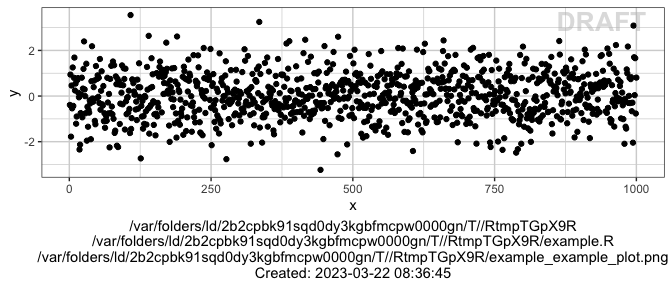

```r
dirs <- list(
  parent_dir = tempdir(),
  rscript_dir = tempdir(),
  rscript_name = "example.R",
  results_dir = tempdir(),
  filename_prefix = "example_")
data <- data.frame(x = 1:1000, y = stats::rnorm(1000))
g <- xgx_plot(data = data, aes(x = x, y = y)) +
  geom_point()
xgx_save(width = 4, height = 4, dirs = dirs, filename_main = "example_plot", status = "DRAFT")
```

The the function `xgx_save` works only with ggplot objects. If the figure that is created is not a ggplot object, it will not work. An alternative is to use `xgx_annotate_status_png` to add the status and filename to png files.

```r
data <- data.frame(x = 1:1000, y = stats::rnorm(1000))
g <- xgx_plot(data = data, aes(x = x, y = y)) +
  geom_point()
filename = file.path(tempdir(), "png_example.png")
ggsave(filename, plot = g, height = 4, width = 4, dpi = 75)
xgx_annotate_status_png(filename, "./ExampleScript.R")
```

```
#> Add footnote to /var/folders/ld/2b2cpbk91sqd0dy3kgbfmcpw0000gn/T//RtmpTGpX9R/png_example.png
```

### Saving tables

We also provide a function `xgx_save_table` for annotating the relevant information to csv files. The annotated table is shown below.

```r
x <- data.frame(ID = c(1, 2), SEX = c("male", "female"))
data <- xgx_save_table(x, dirs = dirs, filename_main = "ExampleTable")
knitr::kable(data)
```

[output not shown]

## Graphics helpers

### xgx theme

The `xgx_theme()` function includes the xGx recommended plot settings. It sets the background to white with light grey lines for the major and minor breaks. This minimizes chart ink as recommended by Edward Tufte. You can add `xgx_theme()` to an existing `ggplot` object, or you can call `xgx_plot()` in place of `ggplot()` for all of your plot initiations.

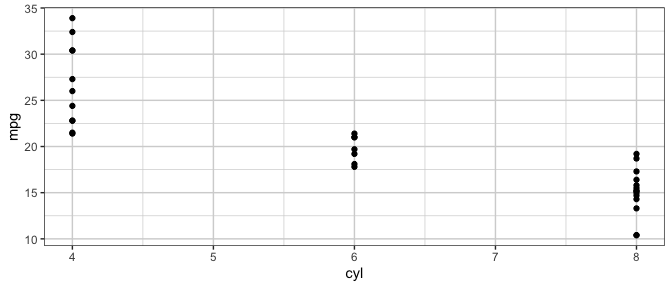

```r
xgx_plot(mtcars, aes(x = cyl, y = mpg)) + geom_point()
```

You may wish to set the theme to `xgx_theme` for your R session, as we do below.

```r
theme_set(xgx_theme())

## Alternative, equivalent function:
xgx_theme_set()
```

```r
# time <- rep(seq(1,10),5)
# id <- sort(rep(seq(1,5), 10))
# conc <- exp(-time)*sort(rep(rlnorm(5),10))
#
# data <- data.frame(time = time, concentration  = conc, id = factor(id))
# xgx_plot() + xgx_geom_spaghetti(data = data, mapping = aes(x = time, y = concentration, group = id, color = id))
#
# xgx_spaghetti(data = data, mapping = aes(x = time, y = concentration, group = id, color = id))
```

### Confidence intervals

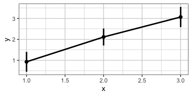

```r
data <- data.frame(x = rep(c(1, 2, 3), each = 20),
                   y = rep(c(1, 2, 3), each = 20) + stats::rnorm(60),
                   group = rep(1:3, 20))

xgx_plot(data,aes(x = x, y = y)) +
    xgx_stat_ci(conf_level = .95)
```

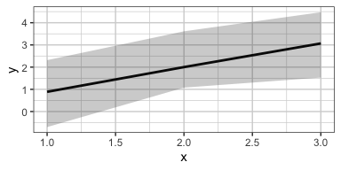

```r
xgx_plot(data,aes(x = x, y = y)) +
    xgx_stat_pi(percent = .95)
```

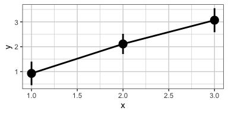

```r
xgx_plot(data,aes(x = x, y = y)) +
    xgx_stat_ci(conf_level = .95, geom = list("pointrange","line"))
```

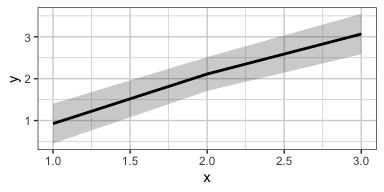

```r
xgx_plot(data,aes(x = x, y = y)) +
    xgx_stat_ci(conf_level = .95, geom = list("ribbon","line"))
```

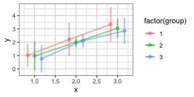

```r
xgx_plot(data,aes(x = x, y = y, group = group, color = factor(group))) +
    xgx_stat_ci(conf_level = .95, alpha =  0.5,
                position = position_dodge(width = 0.5))
```

The default settings calculate the confidence interval based on the Student t Distribution (assuming normally distributed data). You can also specify “lognormal”“,”binomial”” or “multinomial”” for the `distribution`. The first will perform the confidence interval operation on the log-scaled data, the second uses the binomial exact confidence interval calculation from the `binom` package, and the third uses `MultinomCI` from the `DescTools` package. The “multinomial”” option is used for ordinal response or categorical data.

Note: you DO NOT need to use both `distribution = "lognormal"` and `scale_y_log10()`, choose only one of these.

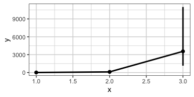

```r
# plotting lognormally distributed data
data <- data.frame(x = rep(c(1, 2, 3), each = 20),
                   y = 10^(rep(c(1, 2, 3), each = 20) + stats::rnorm(60)),
                   group = rep(1:3, 20))
xgx_plot(data, aes(x = x, y = y)) +
 xgx_stat_ci(conf_level = 0.95, distribution = "lognormal")
```

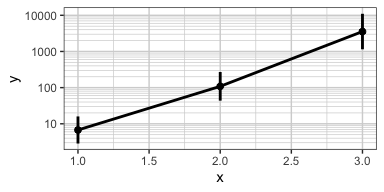

```r
# note: you DO NOT need to use both distribution = "lognormal" and scale_y_log10()
xgx_plot(data,aes(x = x, y = y)) +
 xgx_stat_ci(conf_level = 0.95) + xgx_scale_y_log10()
```

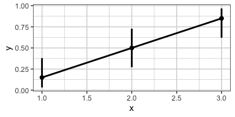

```r
# plotting binomial data
data <- data.frame(x = rep(c(1, 2, 3), each = 20),
                  y = rbinom(60, 1, rep(c(0.2, 0.6, 0.8), each = 20)),
                  group = rep(1:3, 20))
xgx_plot(data, aes(x = x, y = y)) +
 xgx_stat_ci(conf_level = 0.95, distribution = "binomial")
```

[output not shown]

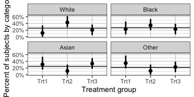

```r
# Example plotting the percent of subjects in a categorical covariate group by treatment.

set.seed(12345)
data = data.frame(x = 120*exp(rnorm(100,0,1)),
                 response = sample(c("Trt1", "Trt2", "Trt3"), 100, replace = TRUE),
                 covariate = factor(sample(c("White","Black","Asian","Other"), 100, replace = TRUE),
                                    levels = c("White", "Black", "Asian", "Other")))

xgx_plot(data = data) +
 xgx_stat_ci(mapping = aes(x = response, response = covariate),
             distribution = "ordinal") +
 xgx_stat_ci(mapping = aes(x = 1, response = covariate), geom = "hline",
             distribution = "ordinal") +
 scale_y_continuous(labels = scales::percent_format()) +
 facet_wrap(~covariate) +
 xlab("Treatment group") + ylab("Percent of subjects by category")
```

`xgx_stat_ci` can now also cut data by quantiles of `x` using the `bins` option, e.g. `bins = 4` will cut the data by quartiles of `x`. You can also supply your own breaks to cut the data.

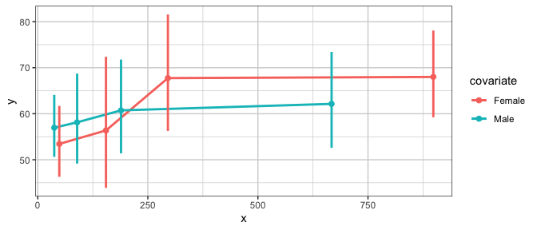

```r
# plotting
set.seed(12345)
data = data.frame(x = 120*exp(rnorm(100,0,1)),
              response = sample(c("Mild","Moderate","Severe"), 100, replace = TRUE),
              covariate = sample(c("Male","Female"), 100, replace = TRUE)) %>%
  mutate(y = (50 + 20*x/(200 + x))*exp(rnorm(100, 0, 0.3)))

# plotting a lognormally distributed variable by quartiles of x
xgx_plot(data = data) +
  xgx_stat_ci(mapping = aes(x = x, y = y, colour = covariate),
              distribution = "lognormal", bins = 4)
```

[output not shown]

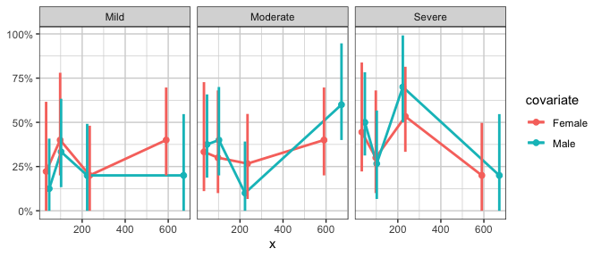

```r
# plotting ordinal or multinomial data, by quartiles of x
xgx_plot(data = data) +
  xgx_stat_ci(mapping = aes(x = x, response = response, colour = covariate),
              distribution = "ordinal", bins = 4) +
  scale_y_continuous(labels = scales::percent_format()) + facet_wrap(~response)
```

[output not shown]

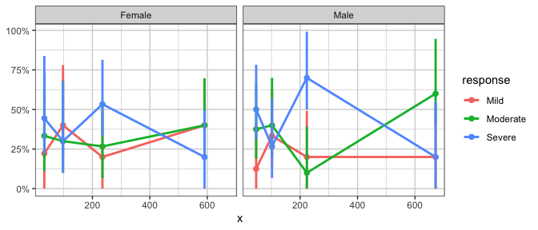

```r
xgx_plot(data = data) +
  xgx_stat_ci(mapping = aes(x = x, response = response, colour = response),
              distribution = "ordinal", bins = 4) +
  scale_y_continuous(labels = scales::percent_format()) + facet_wrap(~covariate)
```

### Nonlinear smoothing (e.g. Emax), and ordinal response smoothing

The current ggplot2::geom_smooth does not allow for plotting confidence bands for method = “nls”, as ggplot2 does not supply a `predictdf` for an object of class `nls`, which geom_smooth silently calls to calculate the ymin and ymax for the confidence bands. The xgxr package includes a definition of `predictdf.nls`, allowing for confidence bands for method = “nls”.

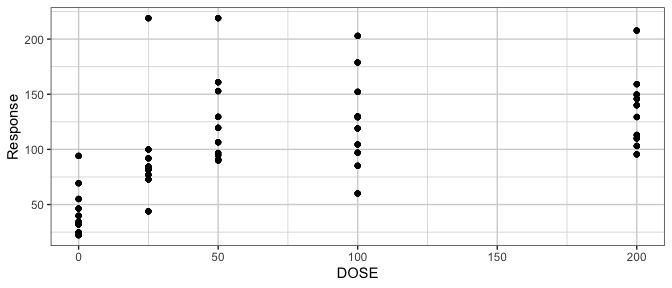

```r
set.seed(123456)

Nsubj <- 10
Doses <- c(0, 25, 50, 100, 200)
Ntot <- Nsubj*length(Doses)
times <- c(0,14,30,60,90)

dat1 <- data.frame(ID = 1:(Ntot),
                   DOSE = rep(Doses, Nsubj),
                   E0 = 50*rlnorm(Ntot, 0, 0.3),
                   Emax = 100*rlnorm(Ntot, 0, 0.3),
                   ED50 = 50*rlnorm(Ntot, 0, 0.3)) %>%
  dplyr::mutate(Response = (E0 + Emax*DOSE/(DOSE + ED50))*rlnorm(Ntot, 0, 0.3)  ) %>%
  merge(data.frame(ID = rep(1:(Ntot), each = length(times)), Time = times), by = "ID")

gg <- xgx_plot(data = dat1, aes(x = DOSE, y = Response))
gg <- gg + geom_point()
gg
```

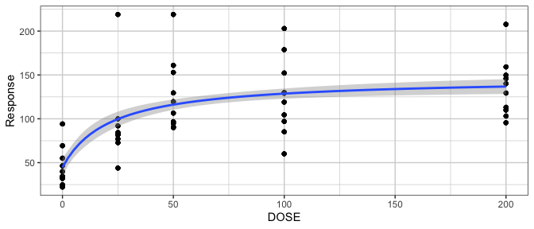

```r
gg + geom_smooth(method = "nlsLM",
                 formula = y ~ E0 + Emax*x/(ED50 + x),
                 method.args = list(start = list(E0 = 1, ED50 = 1, Emax = 1),
                                    lower = c(-Inf, 0, -Inf)))
```

xgxr also includes an Emax smooth function called `xgx_geom_smooth_emax` which utilizes the “nlsLM” method, and silently calls the `predictdf.nls` defined by xgxr.

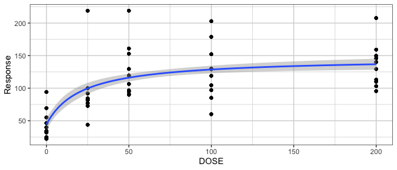

```r
gg + xgx_geom_smooth_emax()
```

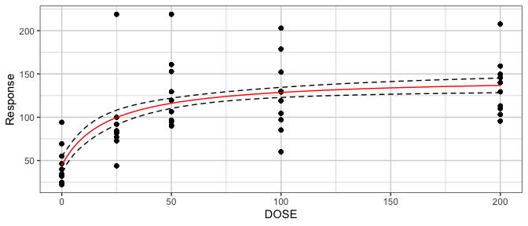

```r
gg +
  xgx_geom_smooth_emax(geom = "ribbon", color = "black", fill = NA, linetype = "dashed") +
  xgx_geom_smooth_emax(geom = "line", color = "red")

```

xgxr also modifies the stats method `predict.nls` for `nls` objects in order to include confidence interval prediction. Upon loading the xgxr package, the `predict` method for class `nls` should be updated to the xgxr version, and include functionality to supply confidence intervals. In order to output the confidence intervals, be sure to specify `interval = "confidence"`. The output will contain a “fit” data.frame with values for “fit”, “lwr” and “upr” representing the prediction and lower and upper confidence intervals.

```r
mod <- nlsLM(formula = Response ~ E0 + Emax * DOSE / (ED50 + DOSE),
             data = dat1,
             start = list(E0 = 1, ED50 = 1, Emax = 1),
                                    lower = c(-Inf, 0, -Inf))

predict(mod,
            newdata = data.frame(DOSE = c(0, 25, 50, 100, 200)),
            se.fit = TRUE)
```

```
#> $fit
#> [1]  44.60368  99.70517 116.14226 128.68292 136.76043
#>
#> $se.fit
#> [1] 5.219335 4.289631 3.012974 2.969559 4.294878
#>
#> $df
#> [1] 247
```

```r
predict(mod,
            newdata = data.frame(DOSE = c(0, 25, 50, 100, 200)),
            se.fit = TRUE, interval = "confidence", level = 0.95)
```

```
#> $fit
#>         fit       lwr       upr
#> 1  44.60368  34.32360  54.88376
#> 2  99.70517  91.25625 108.15409
#> 3 116.14226 110.20786 122.07666
#> 4 128.68292 122.83404 134.53181
#> 5 136.76043 128.30118 145.21969
#>
#> $se.fit
#> [1] 5.219335 4.289631 3.012974 2.969559 4.294878
#>
#> $df
#> [1] 247
```

xgxr also includes ordinal response smoothing as an option under the `xgx_stat_smooth` function, indicated by `method = "polr"`. This requires a dataset of x values and response values, to be defined in the mapping. This method also allows defining of color, fill, facet, linetype, etc. by the response category, while preserving the ordinal response fit across these categories.

```
#> In xgx_stat_smooth:
#>   The following aesthetics are identical to response: PANEL, colour, fill
#>   These will be used for differentiating response groups in the resulting plot.
#> In xgx_stat_smooth:
#>   response should be a factor, converting to factor using as.factor(response) with default levels
```

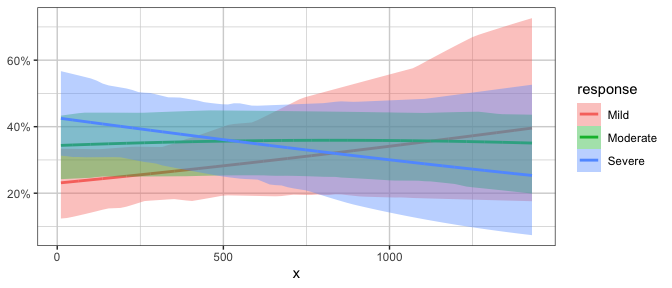

```r
# example with ordinal data (method = "polr")
set.seed(12345)
data = data.frame(x = 120*exp(stats::rnorm(100,0,1)),
                  response = sample(c("Mild","Moderate","Severe"), 100, replace = TRUE),
                  covariate = sample(c("Male","Female"), 100, replace = TRUE)) %>%
  dplyr::mutate(y = (50 + 20*x/(200 + x))*exp(stats::rnorm(100, 0, 0.3)))

# example coloring by the response categories
xgx_plot(data = data) +
  xgx_stat_smooth(mapping = ggplot2::aes(x = x, response = response,
                                         colour = response, fill = response),
                  method = "polr") +
  ggplot2::scale_y_continuous(labels = scales::percent_format())
```

```
#> In xgx_stat_smooth:
#>   The following aesthetics are identical to response: PANEL
#>   These will be used for differentiating response groups in the resulting plot.
#> In xgx_stat_smooth:
#>   The following aesthetics are different from response: colour, fill
#>   These will be used to divide the data into different groups before calculating summary statistics on the response.
#> In xgx_stat_smooth:
#>   response should be a factor, converting to factor using as.factor(response) with default levels
```

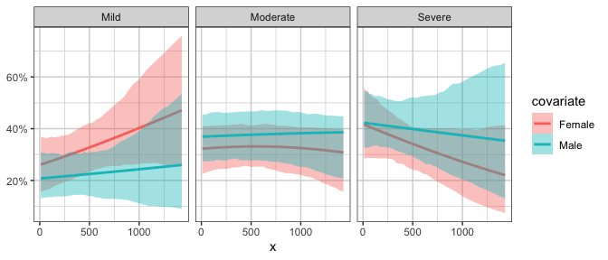

```r
# example faceting by the response categories, coloring by a different covariate
xgx_plot(data = data) +
  xgx_stat_smooth(mapping = ggplot2::aes(x = x, response = response,
                                         colour = covariate, fill = covariate),
                  method = "polr", level = 0.80) +
  ggplot2::facet_wrap(~response) +
  ggplot2::scale_y_continuous(labels = scales::percent_format())
```

### Nice log scale

This version of the log scale function shows the tick marks between the major breaks (i.e. at 1, 2, 3, … 10, instead of just 1 and 10). It also uses
$$10^x$$
notation when the labels are base 10 and are very small or very large (<.001 or >9999)

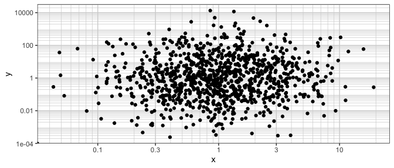

```r
df <- data.frame(x = c(0, stats::rlnorm(1000, 0, 1)),
                 y = c(0, stats::rlnorm(1000, 0, 3)))
xgx_plot(data = df, aes(x = x, y = y)) +
  geom_point() +
  xgx_scale_x_log10() +
  xgx_scale_y_log10()
```

### Reverse log transform

This transform is useful for plotting data on a percentage scale that can approach 100% (such as receptor occupancy data).

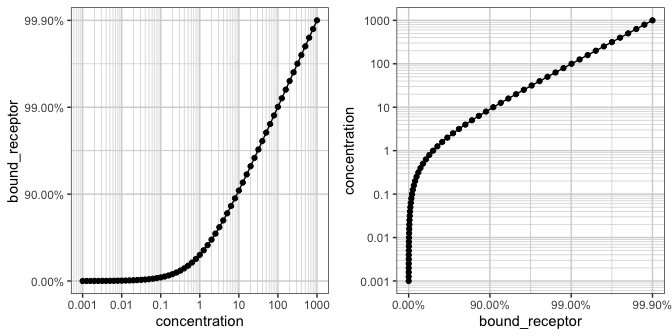

```r
conc <- 10^(seq(-3, 3, by = 0.1))
ec50 <- 1
data <- data.frame(concentration = conc,
                  bound_receptor = 1 * conc / (conc + ec50))
gy <- xgx_plot(data, aes(x = concentration, y = bound_receptor)) +
  geom_point() +
  geom_line() +
  xgx_scale_x_log10() +
  xgx_scale_y_reverselog10()

gx <- xgx_plot(data, aes(x = bound_receptor, y = concentration)) +
  geom_point() +
  geom_line() +
  xgx_scale_y_log10() +
  xgx_scale_x_reverselog10()

gridExtra::grid.arrange(gy, gx, nrow = 1)
```

### Nice scale for percent change data

This transform is useful for plotting percent change from baseline data. Percent change data can range from -100% to +Inf%, and depending on the range of the data, a linear scale can lose the desired resolution. This transform plots percent change data on a scale of log10(PCHG + 100%), similar to a log scale of ratio to baseline.

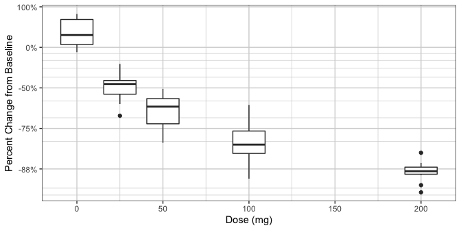

```r
Nsubj <- 10
Doses <- c(0, 25, 50, 100, 200)
Ntot <- Nsubj*length(Doses)
times <- c(0,14,30,60,90)

dat1 <- data.frame(ID = 1:(Ntot),
                   DOSE = rep(Doses, Nsubj),
                   PD0 = rlnorm(Ntot, log(100), 1),
                   Kout = exp(rnorm(Ntot,-2, 0.3)),
                   Imax = 1,
                   ED50 = 25) %>%
  dplyr::mutate(PDSS = PD0*(1 - Imax*DOSE/(DOSE + ED50))*exp(rnorm(Ntot, 0.05, 0.3))  ) %>%
  merge(data.frame(ID = rep(1:(Ntot), each = length(times)), Time = times), by = "ID") %>%
  dplyr::mutate(PD = ((PD0 - PDSS)*(exp(-Kout*Time)) + PDSS),
                PCHG = (PD - PD0)/PD0)

ggplot2::ggplot(dat1 %>% subset(Time == 90),
                ggplot2::aes(x = DOSE, y = PCHG, group = DOSE)) +
  ggplot2::geom_boxplot() +
  xgx_theme() +
  xgx_scale_y_percentchangelog10() +
  ylab("Percent Change from Baseline") +
  xlab("Dose (mg)")
```

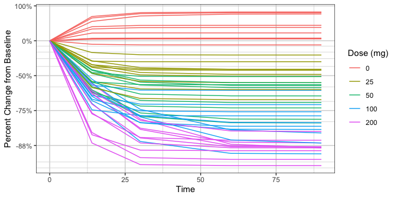

```r
ggplot2::ggplot(dat1,
                ggplot2::aes(x = Time, y = PCHG, group = ID, color = factor(DOSE))) +
  ggplot2::geom_line() +
  xgx_theme() +
  xgx_scale_y_percentchangelog10() +
  guides(color = guide_legend(title = "Dose (mg)")) +
  ylab("Percent Change from Baseline")
```

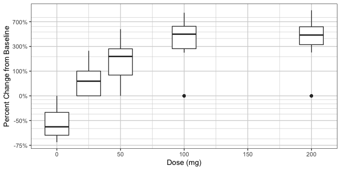

```r
dat2 <- data.frame(ID = 1:(Ntot),
                  DOSE = rep(Doses, Nsubj),
                  PD0 = rlnorm(Ntot, log(100), 1),
                  Kout = exp(rnorm(Ntot,-2, 0.3)),
                  Emax = 50*rlnorm(Ntot, 0, 0.3),
                  ED50 = 300) %>%
 dplyr::mutate(PDSS = PD0*(1 + Emax*DOSE/(DOSE + ED50))*exp(rnorm(Ntot, -1, 0.3))  ) %>%
  merge(data.frame(ID = rep(1:(Ntot), each = length(times)), Time = times), by = "ID") %>%
  dplyr::mutate(PD = ((PD0 - PDSS)*(exp(-Kout*Time)) + PDSS),
                PCHG = (PD - PD0)/PD0)

ggplot2::ggplot(dat2, ggplot2::aes(x = DOSE, y = PCHG, group = DOSE)) +
  ggplot2::geom_boxplot() +
  xgx_theme() +
  xgx_scale_y_percentchangelog10() +
  ylab("Percent Change from Baseline") +
  xlab("Dose (mg)")
```

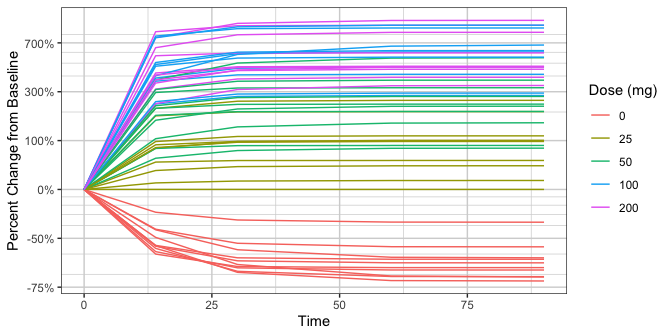

```r
ggplot2::ggplot(dat2,
                ggplot2::aes(x = Time, y = PCHG, group = ID, color = factor(DOSE))) +
  ggplot2::geom_line() +
  xgx_theme() +
  xgx_scale_y_percentchangelog10() +
  guides(color = guide_legend(title = "Dose (mg)")) +
  ylab("Percent Change from Baseline")
```

### Scaling x-axis as a time scale

For time, it’s often good for the x ticks to be spaced in a particular way. For instance, for hours, subdividing in increments by 24, 12, 6, and 3 hours can make more sense than by 10 or 100. Similarly for days, increments of 7 or 28 days are preferred over 5 or 10 days. `xgx_scale_x_time_units` allows for this, where it is the input and output units.

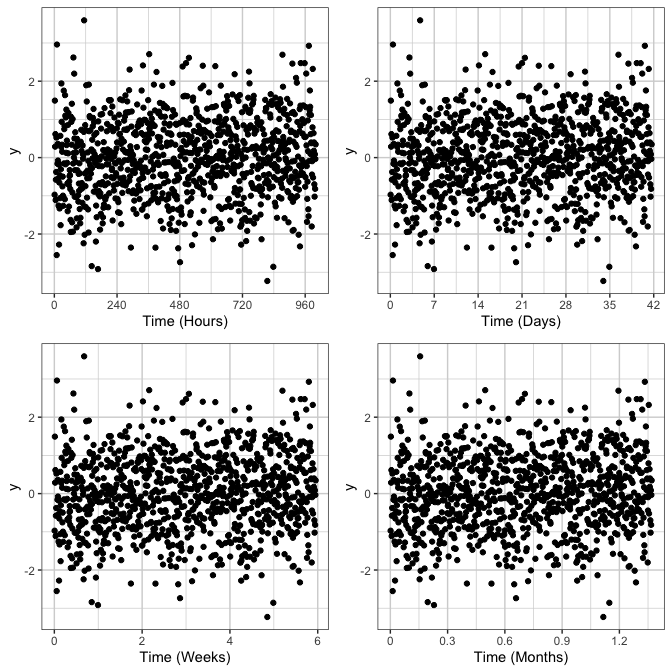

```r
data <- data.frame(x = 1:1000, y = stats::rnorm(1000))
g <- xgx_plot(data = data, aes(x = x, y = y)) +
  geom_point()
g1 <- g + xgx_scale_x_time_units(units_dataset = "hours", units_plot = "hours")
g2 <- g + xgx_scale_x_time_units(units_dataset = "hours", units_plot = "days")
g3 <- g + xgx_scale_x_time_units(units_dataset = "hours", units_plot = "weeks")
g4 <- g + xgx_scale_x_time_units(units_dataset = "hours", units_plot = "months")

gridExtra::grid.arrange(g1, g2, g3, g4, nrow = 2)
```

## Data checking

### Numerical check

We’ve found that during exploration, it can be extremely important to check the dataset for issues. This can be done using the `xgx_check_data` or `xgx_summarize_data` function (the two functions are identical).

```r
data <- mad_missing_duplicates %>%
  filter(CMT %in% c(1, 2, 3)) %>%
  rename(DV      = LIDV,
         YTYPE   = CMT,
         USUBJID = ID)
covariates <- c("WEIGHTB", "SEX")
check <- xgx_check_data(data, covariates)
knitr::kable(check$summary)
```

| Category | Description | YTYPE | Statistic | Value |
| --- | --- | --- | --- | --- |
| Patients | Number of Patients | - | 60 | 60 |
| MDV | Number of patients with zero PK or PD observations | all | 0 | 0 |
| MDV | Number of Missing Data Points (MDV==1 and EVID==0) | 1 | 0 | 0 |
| MDV | Number of Missing Data Points (MDV==1 and EVID==0) | 2 | 99 | 99 |
| MDV | Number of Missing Data Points (MDV==1 and EVID==0) | 3 | 0 | 0 |
| Dose | Number of non-zero doses | - | 300 | 300 |
| Dose | Number of zero doses (AMT==0) | - | 60 | 60 |
| Dose | Number of patients that never received drug | - | 10 | 10 |
| DV | Number of Data Points | 1 | 360 | 360 |
| DV | Number of Data Points | 2 | 1309 | 1309 |
| DV | Number of Data Points | 3 | 600 | 600 |
| DV | Number of Data Points per Individual | 1 | min = 6, median = 6, max = 6 | 6 |
| DV | Number of Data Points per Individual | 2 | min = 26, median = 26, max = 27 | 26 |
| DV | Number of Data Points per Individual | 3 | min = 10, median = 10, max = 10 | 10 |
| DV | Number of Data Points with zero value (DV==0) | 1 | 0 | 0 |
| DV | Number of Data Points with zero value (DV==0) | 2 | 0 | 0 |
| DV | Number of Data Points with zero value (DV==0) | 3 | 0 | 0 |
| DV | Number of Data Points with NA (is.na(DV)) | 1 | 0 | 0 |
| DV | Number of Data Points with NA (is.na(DV)) | 2 | 8 | 8 |
| DV | Number of Data Points with NA (is.na(DV)) | 3 | 0 | 0 |
| DV+TIME | Multiple measurements at same time | 1 | 0 | 0 |
| DV+TIME | Multiple measurements at same time | 2 | 32 | 32 |
| DV+TIME | Multiple measurements at same time | 3 | 0 | 0 |
| CENS | Number of Censored Data Points | 1 | 0 (0%) | 0 |
| CENS | Number of Censored Data Points | 2 | 9 (1%) | 9 |
| CENS | Number of Censored Data Points | 3 | 4 (1%) | 4 |
| All Columns | Negative Values (number) | - | DV:12 | 12 |
| All Columns | Missing Values (number) | - | DV:368 | 368 |

```r
knitr::kable(head(check$data_subset))
```

| Data_Check_Issue | ID | TIME | DV | CENS | YTYPE |
| --- | --- | --- | --- | --- | --- |
| is.na(DV) | 15 | 0.000 | NA | 0 | 2 |
| is.na(DV) | 21 | 127.858 | NA | 0 | 2 |
| is.na(DV) | 22 | 216.537 | NA | 0 | 2 |
| is.na(DV) | 40 | 156.563 | NA | 0 | 2 |
| is.na(DV) | 47 | 120.300 | NA | 0 | 2 |
| is.na(DV) | 50 | 71.814 | NA | 0 | 2 |

You can also get an overview of the covariates in the dataset with `xgx_summarize_covariates`. The covariate summaries are also provided in the `xgx_check_data` and `xgx_summarize_data` functions.

```r
covar <- xgx_summarize_covariates(data,covariates)
knitr::kable(covar$cts_covariates)
```

| Covariate | Nmissing | min | 25th | median | 75th | max |
| --- | --- | --- | --- | --- | --- | --- |
| WEIGHTB | 0 | 52.8 | 69.2 | 78.9 | 89.85 | 109 |

```r
knitr::kable(covar$cat_covariates)
```

| Covariate | Nmissing | Ndistinct | Value (Count) |
| --- | --- | --- | --- |
| SEX | 0 | 2 | Female (30), Male (30) |